# Shape - Data Science

pyproject.toml content for reproducibility:

```
[tool.poetry]
name = "shape"
version = "0.1.0"
description = ""
authors = ["vitaliset <carlo_lemos@hotmail.com>"]
readme = "README.md"

[tool.poetry.dependencies]
python = "^3.10"
jupyter = "^1.0.0"
scikit-learn = "^1.3.0"
pandas = "^2.0.3"
matplotlib = "^3.7.2"
openpyxl = "^3.1.2"
tqdm = "^4.66.1"

[build-system]
requires = ["poetry-core"]
build-backend = "poetry.core.masonry.api"
```

```python
import functools
import numpy as np
import pandas as pd
import matplotlib.pyplot as plt
import matplotlib.patches as mpatches
plt.rcParams.update({"font.size": 8})

from sklearn.base import BaseEstimator, TransformerMixin, ClassifierMixin
from sklearn.utils import check_array, check_random_state
from sklearn.metrics import roc_auc_score, fbeta_score, make_scorer, f1_score
from sklearn.model_selection import train_test_split
from sklearn.pipeline import make_pipeline
from sklearn.compose import ColumnTransformer
from sklearn.preprocessing import StandardScaler, TargetEncoder, FunctionTransformer
from sklearn.linear_model import LogisticRegression
from sklearn.ensemble import RandomForestClassifier
from sklearn.inspection import permutation_importance

def all_equal_elements(iterator):
    iterator = iter(iterator)
    try:
        first = next(iterator)
    except StopIteration:
        return True
    return all(first == x for x in iterator)

def bootstrap_metric(metric, *args, random_state=42, n_bootstrap=20, **kwargs):
    """https://github.com/dihanster/datalib/pull/12"""
    args = [check_array(v, ensure_2d=False, dtype=None) for v in args]
    kwargs = {k: check_array(v, ensure_2d=False, dtype=None) for k, v in kwargs.items()}
    if not all_equal_elements(
        [len(array) for array in list(kwargs.values()) + list(args)]
    ):
        raise ValueError(
            "All the elements to be bootstraped (*args and **kwargs) "
            "are not equal in length."
        )
    size = len((list(kwargs.values()) + args)[0])
    metric(*args, **kwargs)
    rng = check_random_state(random_state)
    random_states = rng.randint(
        low=0, high=2**32 - 1, size=n_bootstrap, dtype=np.int64
    )
    metric_list = []
    for rs in random_states:
        idx = check_random_state(rs).choice(a=size, size=size, replace=True)
        bootstrap_args = [v[idx] for v in args]
        bootstrap_kwargs = {k: v[idx] for k, v in kwargs.items()}
        metric_round = metric(*bootstrap_args, **bootstrap_kwargs)
        metric_list.append(metric_round)
    return np.array(metric_list)
```

# Reading data

```python
df_raw = pd.read_excel("O_G_Equipment_Data.xlsx")
df_raw.head(3)
```

|  | Cycle | Preset_1 | Preset_2 | Temperature | Pressure | VibrationX | VibrationY | VibrationZ | Frequency | Fail |
| --- | --- | --- | --- | --- | --- | --- | --- | --- | --- | --- |
| 0 | 1 | 3 | 6 | 44.235186 | 47.657254 | 46.441769 | 64.820327 | 66.454520 | 44.483250 | False |
| 1 | 2 | 2 | 4 | 60.807234 | 63.172076 | 62.005951 | 80.714431 | 81.246405 | 60.228715 | False |
| 2 | 3 | 2 | 1 | 79.027536 | 83.032190 | 82.642110 | 98.254386 | 98.785196 | 80.993479 | False |

```python
df_raw.info()
```

```
<class 'pandas.core.frame.DataFrame'>
RangeIndex: 800 entries, 0 to 799
Data columns (total 10 columns):
 #   Column       Non-Null Count  Dtype
---  ------       --------------  -----
 0   Cycle        800 non-null    int64
 1   Preset_1     800 non-null    int64
 2   Preset_2     800 non-null    int64
 3   Temperature  800 non-null    float64
 4   Pressure     800 non-null    float64
 5   VibrationX   800 non-null    float64
 6   VibrationY   800 non-null    float64
 7   VibrationZ   800 non-null    float64
 8   Frequency    800 non-null    float64
 9   Fail         800 non-null    bool
dtypes: bool(1), float64(6), int64(3)
memory usage: 57.2 KB
```

The variable types seem appropriate, and we have no null values. We have a total of 800 rows.

# 1 – Calculate how many times the equipment has failed

```python
df_raw.Fail.sum(), df_raw.Fail.mean()
```

```
(66, 0.0825)
```

The equipment failed 66 times in these 800 cycles.

```python
df = (
    df_raw.rename(columns=str.lower)
    .assign(fail=lambda df_: df_.fail.astype(int))
    .set_index("cycle")
)

categorical_features = ["preset_1", "preset_2"]
continuous_features = [
    "temperature",
    "pressure",
    "vibrationx",
    "vibrationy",
    "vibrationz",
    "frequency",
]
```

# Train test split

From now on, as any analysis I perform can provide insights into how I will model the problem, I prefer to make a temporal split between training and testing based on cycles. This is to avoid overfitting and to obtain a final metric value that reflects reality, similar to the value we would get when putting the model into production.

```python
def out_of_time_train_test_split(df, test_size=0.2, gap=10):
    return (
        df.loc[lambda df_: df_.index < (1 - test_size) * df.index.max() - gap],
        df.loc[lambda df_: df_.index >= (1 - test_size) * df.index.max()],
    )

df_train, df_test = out_of_time_train_test_split(df)
```

```python
print(f"Cycle range for train set: ({df_train.index.min()}, {df_train.index.max()})")
print(f"Cycle range for test set: ({df_test.index.min()}, {df_test.index.max()})")
```

```
Cycle range for train set: (1, 629)
Cycle range for test set: (640, 800)
```

# 2 – Categorize equipment failures by setups configurations (preset 1 and preset 2)

To be honest, this question wasn't clear to me. One possible interpretation would be an analysis of how the occurrence of failures is distributed among different configurations of `preset_1` and `preset_2`.

We can calculate how failures occur on average across the cycles.

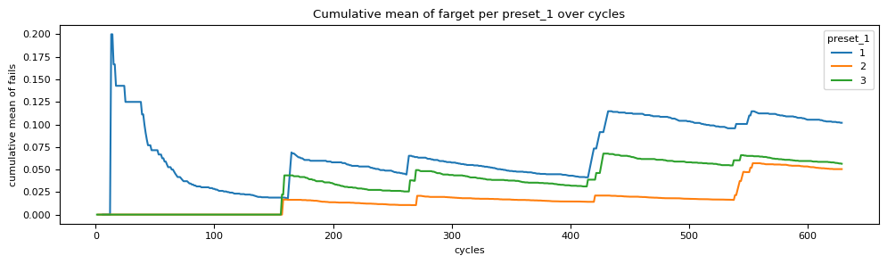

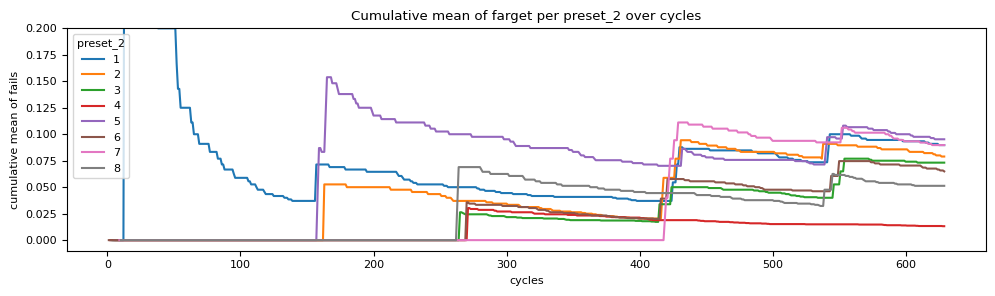

```python
def plot_cummulative_mean_per_category(df, category, ylim=None):
    fig, ax = plt.subplots(figsize=(10, 3))
    grouped = df.reset_index().groupby(["cycle", category])["fail"].mean().reset_index()
    pivot_df = grouped.pivot(index="cycle", columns=category, values="fail")
    cumulative_mean_df = pivot_df.expanding().mean()
    cumulative_mean_df.plot(ax=ax)
    ax.set_title(f"Cumulative mean of farget per {category} over cycles")
    ax.set_ylabel("cumulative mean of fails")
    ax.set_xlabel("cycles")
    if ylim is not None:
        ax.set_ylim(ylim)
    plt.tight_layout()

plot_cummulative_mean_per_category(df_train, "preset_1")
plot_cummulative_mean_per_category(df_train, "preset_2", (-0.01, 0.2))
```

The cumulative average informs us that there are `preset` configurations that are more prone to failures than others. For example, in `preset_1`, it seems that configuration 1 is almost always higher (in terms of average failures) than configuration 3, which is almost always higher than configuration 2.

```python
def col_name_merge(df):
    df.columns = ["_".join(col) for col in df.columns]
    return df

(
    df_train
    .reset_index()
    .groupby("preset_1")
    .agg({"cycle": ["count"], "fail": ["sum", "mean"]})
    .pipe(col_name_merge)
    .reset_index()
)
```

|  | preset_1 | cycle_count | fail_sum | fail_mean |
| --- | --- | --- | --- | --- |
| 0 | 1 | 216 | 22 | 0.101852 |
| 1 | 2 | 218 | 11 | 0.050459 |
| 2 | 3 | 195 | 11 | 0.056410 |

```python
(
    df_train
    .reset_index()
    .groupby("preset_2")
    .agg({"cycle": ["count"], "fail": ["sum", "mean"]})
    .pipe(col_name_merge)
    .reset_index()
)
```

|  | preset_2 | cycle_count | fail_sum | fail_mean |
| --- | --- | --- | --- | --- |
| 0 | 1 | 78 | 7 | 0.089744 |
| 1 | 2 | 76 | 6 | 0.078947 |
| 2 | 3 | 82 | 6 | 0.073171 |
| 3 | 4 | 76 | 1 | 0.013158 |
| 4 | 5 | 84 | 8 | 0.095238 |
| 5 | 6 | 77 | 5 | 0.064935 |
| 6 | 7 | 78 | 7 | 0.089744 |
| 7 | 8 | 78 | 4 | 0.051282 |

# 3 – Categorize equipment failures by their nature/root cause according to parameter readings (temperature, pressure, and others)

First, let's simplify this analysis by looking only at cases with extreme (large) values, rather than small values. It could be the case that a machine with low temperature experiences a failure, but when examining the histograms that show how failures are distributed, we see that this doesn't occur.

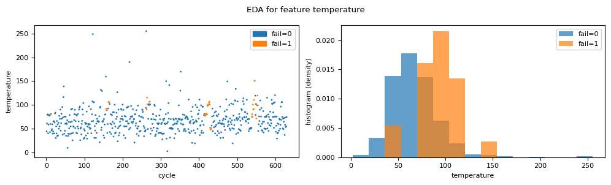

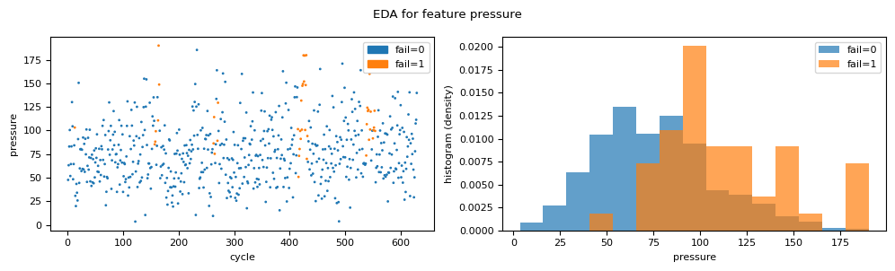

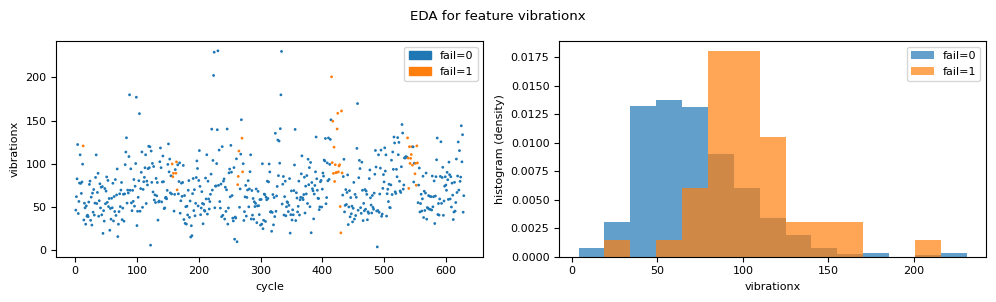

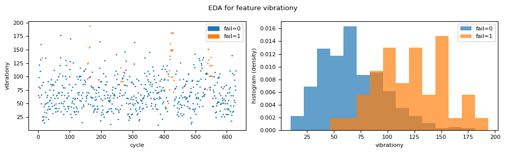

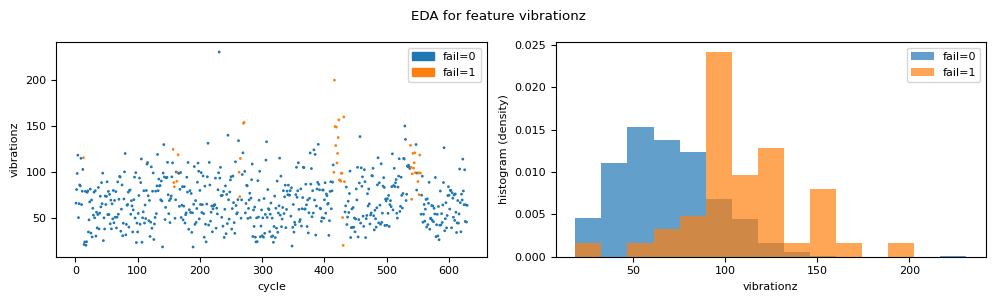

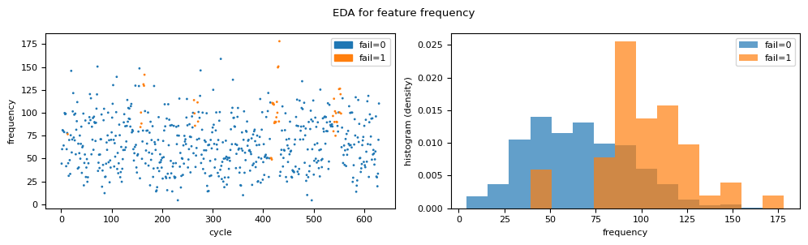

```python
def map_color(fail_value):
    color_map = {0: 'C0', 1: 'C1'}
    return color_map.get(fail_value, 'C3')

def plot_scatter(df, feature, ax):
    scatter = ax.scatter(df.index, df[feature], s=1, c=df.fail.apply(map_color))
    ax.set_xlabel("cycle")
    ax.set_ylabel(feature)
    handles = [mpatches.Patch(color=map_color(i), label=f"fail={i}") for i in df.fail.unique()]
    ax.legend(handles=handles)
    return ax

def plot_histogram(df, feature, ax, bins):
    _, bin_values = np.histogram(df[feature], bins=bins)
    ax.hist(df.query("fail == 0")[feature], bins=bin_values, density=True, color="C0", alpha=0.7, label="fail=0")
    ax.hist(df.query("fail == 1")[feature], bins=bin_values, density=True, color="C1", alpha=0.7, label="fail=1")
    ax.set_xlabel(feature)
    ax.set_ylabel("histogram (density)")
    ax.legend()
    return ax

def eda_per_feature(df, feature, bins=10):
    fig, ax = plt.subplots(ncols=2, figsize=(10, 3))
    plot_scatter(df, feature, ax[0])
    plot_histogram(df, feature, ax[1], bins=bins)
    fig.suptitle(f"EDA for feature {feature}")
    plt.tight_layout()

for feature in continuous_features:
    eda_per_feature(df_train, feature, bins=15)
```

Let's build a dictionary of "above normal" measurements for a specific variable. To determine the meaning of "above normal," we could use a statistical measure of position such as a high percentile. For example, we could calculate:

```
dict_feat_big = df_train.filter(continuous_features).quantile(0.90).to_dict()
```

But for this analysis, I've decided to choose this value with the classification modeling in mind.

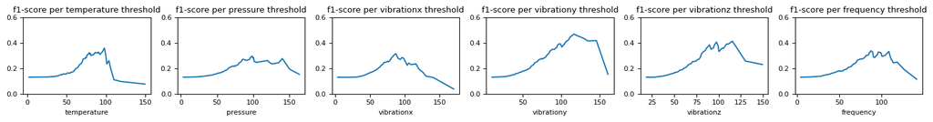

```python
fig, ax = plt.subplots(ncols=6, figsize=(15, 2))
dict_feat_big = {}
for i, feature in enumerate(continuous_features):
    feature_grid = df_train[feature].sort_values()[::10].to_list()
    f1_score_of_value = []
    for value in feature_grid:
        f1_of_value = f1_score(df_train.fail, (df_train[feature] > value).astype(int))
        f1_score_of_value.append(f1_of_value)
    dict_feat_big[feature] = feature_grid[np.argmax(f1_score_of_value)]
    ax[i].plot(feature_grid, f1_score_of_value)
    ax[i].set_xlabel(feature)
    ax[i].set_title(f"f1-score per {feature} threshold")
    ax[i].set_ylim(0, 0.6)
plt.tight_layout()
```

```python
dict_feat_big
```

```
{'temperature': 97.92268366255618,
 'pressure': 98.60870649338392,
 'vibrationx': 87.18449316423877,
 'vibrationy': 116.62396690321243,
 'vibrationz': 115.44667140295948,
 'frequency': 87.46178239249589}
```

$\oint$ *This is quite similar to a decision tree classifier with a depth of 1, choosing its split value. If we wanted to go with this approach, we could do something like:*

```
from sklearn.tree import DecisionTreeClassifier
dict_feat_big = {}
for feature in continuous_features:
    dict_feat_big[feature] = (
        DecisionTreeClassifier(max_depth=1)
        .fit(df_train[[feature]], df_train.fail)
        .tree_.threshold[0]
    )
```

For each specific feature, I am computing the average number of failures within both the "high value" group and the "normal value" group:

```python
def agg_pivot(df, cols):
    return pd.concat(
        [
            df.pivot_table(values="fail", index=col).rename(columns={"fail": col})
            for col in cols
        ],
        axis=1,
    )

(
    df_train.assign(
        **{
            f"{feature}_big": lambda df_, feature=feature: (
                df_[feature] > dict_feat_big[feature]
            ).astype(int)
            for feature in continuous_features
        }
    )
    .pipe(agg_pivot, cols=list(map(lambda col: col + "_big", continuous_features)))
    .reset_index()
    .rename(columns={"index": "flag_is_big"})
)
```

|  | flag_is_big | temperature_big | pressure_big | vibrationx_big | vibrationy_big | vibrationz_big | frequency_big |
| --- | --- | --- | --- | --- | --- | --- | --- |
| 0 | 0 | 0.039927 | 0.029724 | 0.019956 | 0.035026 | 0.045685 | 0.017354 |
| 1 | 1 | 0.282051 | 0.189873 | 0.196629 | 0.413793 | 0.447368 | 0.214286 |

It does seem that there are indeed certain extreme values of the measured parameters that are more correlated with failures than others. In any case, all of them appear to be risk indicators, given their high frequency when they are extreme.

# 4 – Create a model using the technique you think is most appropriate and measure its performance

$\oint$ *One interesting thing that the graphs show us is that failures seem to be clustered in nearby cycles. In this case, I assume that it's because the issue hasn't been corrected and the equipment remains impaired for a few cycles. A model that uses recent past failures to predict future ones will likely perform very well, but it doesn't seem very useful for solving the problem of anticipating failure in advance and performing maintenance shortly before the actual failure occurs.*

I believe having a good recall (i.e., correctly identifying most of the actual failure cases) is extremely relevant. This would imply having a somewhat conservative model, so it's important to balance and maintain a reasonable precision (the percentage of times the predicted failure is actually a failure) as well. To achieve this, I will use an `fbeta_score` with `beta=2` to give twice the weight (in the harmonic mean) to recall.

```python
f2_score = functools.partial(fbeta_score, beta=2)

df_train_model, df_train_threshold = train_test_split(
    df_train, test_size=0.2, stratify=df_train.fail, random_state=0
)

def return_X_y(df):
    return df.drop(columns=["fail"]), df["fail"].values

X_train_model, y_train_model = return_X_y(df_train_model)
X_train_threshold, y_train_threshold = return_X_y(df_train_threshold)
X_test, y_test = return_X_y(df_test)
```

## SimpleFlagModel

It's interesting to see a simpler benchmark for performance comparison. Our simple benchmark will be a count of the flag covariates created in the previous exercise. To obtain "hard predictions" from this `decision_function`, we can check if this count is greater than zero or not (later, we'll explore a more refined way to choose this threshold).

```python
class SimpleFlagModel(BaseEstimator, ClassifierMixin):
    def predict(self, X):
        return (X > 0).any(axis=1).astype(int)

    def decision_function(self, X):
        return (X > 0).sum(axis=1).astype(int)

    def predict_proba(self, X):
        decision_to_proba = self.decision_function(X) / X.shape[1]
        return np.vstack([1 - decision_to_proba, decision_to_proba]).T
```

This model already presents a fairly high `roc_auc_score`, indicating that it's a reasonably easy problem to predict.

In all analyses, I'm consistently calculating the mean of the metric on the test set and its standard deviation using bootstrap resampling. This approach helps us gain insight into the variability of the metric as well.

```python
def create_big_cols_and_filter(X):
    return X.assign(
        **{
            f"{feature}_big": lambda df_, feature=feature: (
                df_[feature] > dict_feat_big[feature]
            ).astype(int)
            for feature in continuous_features
        }
    ).filter(like="big")

benchmark_model = make_pipeline(
    FunctionTransformer(func=create_big_cols_and_filter), SimpleFlagModel()
)

roc_test_benchmark_sample = bootstrap_metric(
    roc_auc_score,
    y_test,
    benchmark_model.decision_function(X_test),
    random_state=42,
    n_bootstrap=100,
)
roc_test_benchmark_sample.mean(), roc_test_benchmark_sample.std()
```

```
(0.9423584790523678, 0.02612075876145035)
```

The `f2_score` might not be as good as the `roc_auc_score`, but it's still reasonable as well.

```python
f2_test_benchmark_sample = bootstrap_metric(
    f2_score, y_test, benchmark_model.predict(X_test), random_state=42, n_bootstrap=100
)
f2_test_benchmark_sample.mean(), f2_test_benchmark_sample.std()
```

```
(0.5753686281553765, 0.06445978006466699)
```

## Optimizing the Decision Threshold

We can improve the selection of the prediction threshold in the 0-1 classification by optimizing it using a chosen metric of interest on a dedicated threshold-tuning dataset.t.

```python
def optmize_threshold_metric(model, X, y, metric, threshold_grid, n_bootstrap=20):
    """https://vitaliset.github.io/threshold-dependent-opt/"""
    metric_values = []
    for t in threshold_grid:
        metric_value = metric(y, (model.predict_proba(X)[:, 1] > t).astype(int))
        metric_values.append(metric_value)
    metric_values = np.array(metric_values)
    best_threshold = threshold_grid[np.argmax(metric_values)]
    return metric_values, best_threshold

threshold_grid = np.linspace(0, 1, 101)
f2_benchmark, best_threshold_benchmark = optmize_threshold_metric(
    benchmark_model, X_train_threshold, y_train_threshold, f2_score, threshold_grid
)
best_threshold_benchmark
```

```
0.34
```

In this case, we obtain a customized threshold (in this case, `0.34`). This results in a significantly improved `f2_score` compared to the previous rule that used `0` as the threshold.

```python
f2_test_benchmark_sample = bootstrap_metric(
    f2_score,
    y_test,
    (benchmark_model.predict_proba(X_test)[:, 1] > best_threshold_benchmark).astype(int),
    random_state=42,
    n_bootstrap=100,
)
np.mean(f2_test_benchmark_sample), np.std(f2_test_benchmark_sample)
```

```
(0.7835150410077155, 0.08390760586085486)
```

Now, let's test more complex models to see if we can surpass the performance of the simple model.

## RandomForestClassifier

```python
rfc = make_pipeline(
    ColumnTransformer(
        [("target", TargetEncoder(random_state=42), categorical_features)],
        remainder="passthrough",
    ),
    RandomForestClassifier(random_state=42),
).fit(X_train_model, y_train_model)
f2_rfc, best_threshold_rfc = optmize_threshold_metric(
    rfc, X_train_threshold, y_train_threshold, f2_score, threshold_grid
)

roc_test_rfc_sample = bootstrap_metric(
    roc_auc_score,
    y_test,
    rfc.predict_proba(X_test)[:, 1],
    random_state=42,
    n_bootstrap=100,
)
roc_test_rfc_sample.mean(), roc_test_benchmark_sample.std()
```

```
(0.9636475128921878, 0.02612075876145035)
```

```python
f2_test_rfc_sample = bootstrap_metric(
    f2_score,
    y_test,
    (rfc.predict_proba(X_test)[:, 1] > best_threshold_rfc).astype(int),
    random_state=42,
    n_bootstrap=100,
)
np.mean(f2_test_rfc_sample), np.std(f2_test_rfc_sample)
```

```
(0.7536348439210129, 0.07891378634825406)
```

The Random Forest model is virtually tied with the simple rule, with overlapping confidence intervals.

## LogisticRegression

```python
lr = make_pipeline(
    ColumnTransformer(
        [("target", TargetEncoder(random_state=42), categorical_features)],
        remainder="passthrough",
    ),
    StandardScaler(),
    LogisticRegression(random_state=42),
).fit(X_train_model, y_train_model)
f2_lr, best_threshold_lr = optmize_threshold_metric(
    lr, X_train_threshold, y_train_threshold, f2_score, threshold_grid
)

roc_test_lr_sample = bootstrap_metric(
    roc_auc_score,
    y_test,
    lr.predict_proba(X_test)[:, 1],
    random_state=42,
    n_bootstrap=100,
)
roc_test_lr_sample.mean(), roc_test_benchmark_sample.std()
```

```
(0.9651275187003268, 0.02612075876145035)
```

```python
f2_test_lr_sample = bootstrap_metric(
    f2_score,
    y_test,
    (lr.predict_proba(X_test)[:, 1] > best_threshold_lr).astype(int),
    random_state=42,
    n_bootstrap=100,
)
np.mean(f2_test_lr_sample), np.std(f2_test_lr_sample)
```

```
(0.8869033738621979, 0.04137214455854708)
```

## Comparing the models

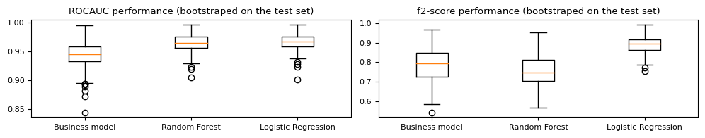

```python
roc_test_samples = [roc_test_benchmark_sample, roc_test_rfc_sample, roc_test_lr_sample]
f2_test_samples = [f2_test_benchmark_sample, f2_test_rfc_sample, f2_test_lr_sample]

fig, ax = plt.subplots(ncols=2, figsize=(10, 2))
ax[0].boxplot(roc_test_samples)
ax[0].set_xticklabels(["Business model", "Random Forest", "Logistic Regression"])
ax[0].set_title("ROCAUC performance (bootstraped on the test set)")
ax[1].boxplot(f2_test_samples)
ax[1].set_xticklabels(["Business model", "Random Forest", "Logistic Regression"])
ax[1].set_title("f2-score performance (bootstraped on the test set)")
plt.tight_layout()
```

I'm a big fan of tree models, but seeing that the Random Forest didn't outperform the simple model composed of "OneRules," it doesn't seem very justifiable to spend time on boosting trees. Doing so might lead to loss of interpretability and increased susceptibility to overfitting, especially since we have limited data. Therefore, my recommendation would be to proceed with the implementation process using logistic regression.

It's a simple model that can even be hard-coded in log-odds scale using SQL if integrating with Python is complex.

# 5 – Analyze variable importance

Logistic regression offers a straightforward way of interpretability: by analyzing the coefficients. Since we applied a `StandardScaler` just before using logistic regression, the scale of the coefficients is comparable. Therefore, by examining their magnitudes, we can intuitively understand which variables the model assigns greater importance to.

```python
pd.DataFrame(
    list(
        zip(X_train_model.columns, np.abs(lr.named_steps["logisticregression"].coef_[0]))
    ),
    columns=["feat", "imp"],
).sort_values("imp", ascending=False)
```

|  | feat | imp |
| --- | --- | --- |
| 7 | frequency | 1.388294 |
| 6 | vibrationz | 1.337616 |
| 5 | vibrationy | 1.179065 |
| 4 | vibrationx | 0.982082 |
| 2 | temperature | 0.780614 |
| 1 | preset_2 | 0.421041 |
| 3 | pressure | 0.284798 |
| 0 | preset_1 | 0.188772 |

Indeed, this ordering of importance aligns reasonably well with more complex techniques for measuring variable importance, such as permutation importance (how much average performance drops when randomizing the values of the respective variable).

```python
perm_imp = permutation_importance(lr, X_test, y_test, scoring="roc_auc")

pd.DataFrame(
    list(zip(X_train_model.columns, perm_imp.importances_mean)), columns=["feat", "imp"]
).sort_values("imp", ascending=False)
```

|  | feat | imp |
| --- | --- | --- |
| 7 | frequency | 0.048659 |
| 5 | vibrationy | 0.042577 |
| 6 | vibrationz | 0.025049 |
| 4 | vibrationx | 0.022237 |
| 2 | temperature | 0.009745 |
| 3 | pressure | 0.009287 |
| 1 | preset_2 | -0.000392 |
| 0 | preset_1 | -0.002681 |